# Case Study: Benchmarking

Angela Sofia Burkhart Colorado

2026-10-21

**NOTE: In this markdown, source is interchangeable with study (e.g., IBD, ZIM), and motif is interchangeable with patterns (e.g., the patterns that DM[H]N searches for).**

## Necessary Packages

IBD datasets were taken from Curtis Huttenhower’s [Inflammatory Bowel Disease Multi’omics Database](https://ibdmdb.org/).

Files used:

1. `ecs_3.tsv.gz` (metagenomes) -> renamed `ecs_3_metaG.tsv`
2. `ecs_3.tsv.gz` (metatranscriptomes) -> renamed `ecs_3_metaT.tsv`
3. `hmp2_metadata_2018-08-20.csv` (metadata)
4. `host_tx_counts.csv` (host transcriptome)

```r
# biocmanager packages
pkgs <- c("org.Hs.eg.db", "KEGGREST", "AnnotationDbi")
missing_pkgs <- pkgs[!sapply(pkgs, requireNamespace, quietly = TRUE)]
if (length(missing_pkgs) > 0) {
  if (!requireNamespace("BiocManager", quietly = TRUE)) install.packages("BiocManager")
  BiocManager::install(missing_pkgs)
}

# import packages
library(readr)
library(vegan)
library(corrplot)
library(tidyverse)
library(car)
library(dplyr)
library(tidyr)
library(ggplot2)
library(purrr)
library(stringr)
library(org.Hs.eg.db)
library(KEGGREST)
library(AnnotationDbi)
library(forcats)
library(tidyverse)
library(broom)
library(gt)
library(patchwork)
library(cowplot)
library(factoextra)
library(emmeans)
library(lme4)
library(lmerTest)
library(broom.mixed)
library(rstatix)
library(ggpubr)
library(performance)
library(corrplot)
library(knitr)
library(betapart)
library(permute)
library(patchwork)

# resolve package conflicts
select    <- dplyr::select
filter    <- dplyr::filter
rename    <- dplyr::rename
mutate    <- dplyr::mutate
first     <- dplyr::first
summarise <- dplyr::summarise
group_by  <- dplyr::group_by
recode    <- dplyr::recode

dir.create("figures", showWarnings = FALSE)

# consistent labeling/order for all figures and tables
experiment_order  <- c("hg_mgx", "hg_mtx", "htx_mgx", "htx_mtx")
experiment_labels <- c(
  hg_mgx  = "Host genome + Metagenome",
  hg_mtx  = "Host genome + Metatranscriptome",
  htx_mgx = "Host transcriptome + Metagenome",
  htx_mtx = "Host transcriptome + Metatranscriptome"
)

# colorblind-safe palette (Okabe-Ito), 4 categories
experiment_colors <- c(
  hg_mgx  = "#E69F00",
  hg_mtx  = "#56B4E9",
  htx_mgx = "#009E73",
  htx_mtx = "#CC79A7"
)

pub_theme <- theme_bw(base_size = 11) +
  theme(
    plot.title      = element_text(hjust = 0.5, face = "bold", size = 12),
    strip.background = element_rect(fill = "grey90"),
    legend.position = "bottom"
  )

# general
options(scipen = 999)
set.seed(5)
```

```r
# read in metadata
meta <- read_csv("data/hmp2_metadata_2018-08-20.csv")

# data wrangling
meta$diagnosis <- factor(meta$diagnosis, levels = c("UC", "CD", "nonIBD"))
```

## Sub-sampling

```r
unique(meta$data_type)

# keeping patients with the following data types
wanted_data <- c("metagenomics", "metatranscriptomics", "host_transcriptomics")

# Filter to for relevant data types
htx <- meta %>%
  filter(data_type == "host_transcriptomics") %>%
  dplyr::select(`Participant ID`, week_num) %>%
  distinct()

mgx <- meta %>%
  filter(data_type == "metagenomics") %>%
  dplyr::select(`Participant ID`, week_num) %>%
  distinct()

mtx <- meta %>%
  filter(data_type == "metatranscriptomics") %>%
  dplyr::select(`Participant ID`, week_num) %>%
  distinct()

# find participant-weeks with host_transcriptomics + metagenomics + metatranscriptomics
triple_match <- htx %>%
  inner_join(mgx, by = c("Participant ID", "week_num")) %>%
  inner_join(mtx, by = c("Participant ID", "week_num"))

# Sanity checks
cat("Participants in triple_match (htx+mgx+mtx):", n_distinct(triple_match$`Participant ID`), "\n")
cat("Total matched participant-weeks:", nrow(triple_match), "\n")

# one triple-matched timepoint per participant (earliest)
chosen <- triple_match %>%
  group_by(`Participant ID`) %>%
  slice_min(week_num, n = 1, with_ties = FALSE) %>%
  ungroup()

# pull full metadata rows for all three data types at matched timepoints
final_rows <- meta %>%
  filter(data_type %in% wanted_data) %>%
  semi_join(chosen, by = c("Participant ID", "week_num"))

table(final_rows$data_type)
n_distinct(final_rows$`Participant ID`)
```

## Directory creation

```r
# ============================================================
# paths to  per-data-type wide TSVs
# ============================================================
data_type_files <- list(
  metagenomics         = "data/ecs_3_metaG.tsv",
  metatranscriptomics  = "data/ecs_3_metaT.tsv",
  host_transcriptomics = "data/host_tx_counts.tsv"
)

# Fixed reference files - same for every participant/week
host_genome_abundance_file <- "data/host_ko_abundance.csv"
host_genome_ko_file        <- "data/noquote_ko_host.txt"

output_root <- "participants/"

# cache paths for mapping tables
gene_ko_map_path <- "data/cache/gene_to_ko_map.rds"
ec_ko_map_path   <- "data/cache/ec_to_ko_map.rds"

# ============================================================
# BUILD ONCE: gene symbol -> KO mapping
# ============================================================
build_gene_to_ko_map <- function(symbols, cache_path = gene_ko_map_path) {
  if (file.exists(cache_path)) {
    return(readRDS(cache_path))
  }

  message("Building gene -> KO mapping (first run only)...")

  sym_to_entrez <- AnnotationDbi::select(
    org.Hs.eg.db,
    keys = unique(symbols),
    keytype = "SYMBOL",
    columns = "ENTREZID"
  ) %>% distinct(SYMBOL, .keep_all = TRUE)

  links <- keggLink("ko", "hsa")  # "hsa:ENTREZID" -> "ko:K00001"
  entrez_to_ko <- tibble(
    ENTREZID = str_remove(names(links), "^hsa:"),
    KO = str_remove(links, "^ko:")
  )

  gene_ko_map <- sym_to_entrez %>%
    left_join(entrez_to_ko, by = "ENTREZID") %>%
    dplyr::select(SYMBOL, KO) %>%
    mutate(KO = ifelse(is.na(KO), "UNMAPPED", KO))

  dir.create(dirname(cache_path), recursive = TRUE, showWarnings = FALSE)
  saveRDS(gene_ko_map, cache_path)
  gene_ko_map
}

# ============================================================
# BUILD ONCE: EC number -> KO mapping
# ============================================================
build_ec_to_ko_map <- function(cache_path = ec_ko_map_path) {
  if (file.exists(cache_path)) {
    return(readRDS(cache_path))
  }

  message("Building EC -> KO mapping (first run only)...")

  links <- keggLink("ko", "ec")  # "ec:1.1.1.1" -> "ko:K00001"
  ec_to_ko <- tibble(
    EC = str_remove(names(links), "^ec:"),
    KO = str_remove(links, "^ko:")
  )

  dir.create(dirname(cache_path), recursive = TRUE, showWarnings = FALSE)
  saveRDS(ec_to_ko, cache_path)
  ec_to_ko
}

# ============================================================
# Load / build both mapping tables up front
# ============================================================
# (symbols arg filled in below, after first host file is read)
ec_to_ko_map <- build_ec_to_ko_map()

# ============================================================
# Cache TSVs so each is read only once
# ============================================================
loaded_csvs <- new.env()
get_csv <- function(dtype) {
  if (is.null(loaded_csvs[[dtype]])) {
    loaded_csvs[[dtype]] <- read_tsv(data_type_files[[dtype]], show_col_types = FALSE)
  }
  loaded_csvs[[dtype]]
}

find_sample_col <- function(df, external_id) {
  matches <- names(df)[str_starts(names(df), fixed(external_id))]
  if (length(matches) == 0) return(NULL)
  matches[1]
}

# Build (or load cached) gene->KO map using the actual host file's gene list
gene_ko_map <- {
  host_preview <- get_csv("host_transcriptomics")
  build_gene_to_ko_map(host_preview[[1]])
}

# ============================================================
# Parse "EC|g__Genus.s__species" into EC + taxonomy, then
# translate EC -> KO and sum abundance for genes/ECs sharing a KO
# ============================================================
parse_ec_taxonomy <- function(feature_vec) {
  # Drop stray comment/header rows that aren't real features
  feature_vec <- feature_vec[!str_starts(feature_vec, "#")]

  # Split off taxonomy first (EC+description | taxonomy)
  parts <- str_split_fixed(feature_vec, "\\|", 2)
  ec_and_desc <- parts[, 1]
  taxonomy <- ifelse(parts[, 2] == "", NA_character_, parts[, 2])

  # Strip the ": description" suffix, keeping bare EC code
  # (leaves UNMAPPED / UNGROUPED untouched since they have no colon)
  ec_clean <- str_trim(str_remove(ec_and_desc, ":.*$"))

  tibble(
    EC = ec_clean,
    taxonomy = taxonomy
  )
}

write_microbe_files <- function(dtype, external_id, abundance_path, ko_path) {
  if (is.null(external_id) || is.na(external_id)) return(invisible(NULL))
  df <- get_csv(dtype)
  feature_col <- names(df)[1]
  sample_col <- find_sample_col(df, external_id)
  if (is.null(sample_col)) {
    warning(paste("No column match for", external_id, "in", dtype))
    return(invisible(NULL))
  }

  # Drop stray header/comment rows BEFORE splitting, so abundance stays aligned
  df_clean <- df %>% dplyr::filter(!str_starts(.data[[feature_col]], "#"))

  parts <- str_split_fixed(df_clean[[feature_col]], "\\|", 2)
  parsed <- tibble(
    EC = str_trim(str_remove(parts[, 1], ":.*$")),
    taxonomy = ifelse(parts[, 2] == "", NA_character_, parts[, 2]),
    Abundance_RPKs = df_clean[[sample_col]]
  )

  translated <- parsed %>%
    dplyr::left_join(ec_to_ko_map, by = "EC") %>%
    dplyr::mutate(KO = dplyr::case_when(
      EC %in% c("UNMAPPED", "UNGROUPED") ~ EC,
      is.na(KO) ~ "UNMAPPED",
      TRUE ~ KO
    )) %>%
    dplyr::group_by(KO, taxonomy) %>%
    dplyr::summarise(Abundance_RPKs = sum(Abundance_RPKs, na.rm = TRUE), .groups = "drop") %>%
    dplyr::filter(Abundance_RPKs != 0) %>%
    dplyr::select(KO, taxonomy, Abundance_RPKs)

  write_csv(translated, abundance_path, na = "NA")
  writeLines(unique(translated$KO), ko_path)
}

# ============================================================
# Host transcriptomics: gene symbol -> KO, summed per KO per sample
# ============================================================
write_host_files <- function(dtype, external_id, abundance_path, ko_path) {
  if (is.null(external_id) || is.na(external_id)) return(invisible(NULL))
  df <- get_csv(dtype)
  feature_col <- names(df)[1]
  sample_col <- find_sample_col(df, external_id)
  if (is.null(sample_col)) {
    warning(paste("No column match for", external_id, "in", dtype))
    return(invisible(NULL))
  }

  translated <- df %>%
    dplyr::select(all_of(feature_col), all_of(sample_col)) %>%
    rename(SYMBOL = 1, Abundance = 2) %>%
    left_join(gene_ko_map, by = "SYMBOL") %>%
    mutate(KO = ifelse(is.na(KO), "UNMAPPED", KO)) %>%
    group_by(KO) %>%
    summarise(Abundance = sum(Abundance, na.rm = TRUE), .groups = "drop") %>%
    filter(Abundance != 0)

  write_csv(translated, abundance_path, na = "NA")
  writeLines(unique(translated$KO), ko_path)
}

# ============================================================
# host_genome is fixed - copy the same reference files every time
# ============================================================
write_host_genome_files <- function(abundance_path, ko_path) {
  file.copy(host_genome_abundance_file, abundance_path, overwrite = TRUE)
  file.copy(host_genome_ko_file, ko_path, overwrite = TRUE)
}

# ============================================================
# Build one pair directory
# ============================================================
copy_pair_files <- function(microbe_dtype, microbe_ext_id, host_dtype, host_ext_id, out_dir) {
  dir.create(out_dir, recursive = TRUE, showWarnings = FALSE)

  write_microbe_files(
    dtype = microbe_dtype, external_id = microbe_ext_id,
    abundance_path = file.path(out_dir, "ko_taxonomy_abundance.csv"),
    ko_path = file.path(out_dir, "noquote_ko.txt")
  )

  if (host_dtype == "host_genome") {
    write_host_genome_files(
      abundance_path = file.path(out_dir, "host_ko_abundance.csv"),
      ko_path = file.path(out_dir, "noquote_ko_host.txt")
    )
  } else if (!is.null(host_ext_id) && !is.na(host_ext_id)) {
    write_host_files(
      dtype = host_dtype, external_id = host_ext_id,
      abundance_path = file.path(out_dir, "host_ko_abundance.csv"),
      ko_path = file.path(out_dir, "noquote_ko_host.txt")
    )
  }
}

# ============================================================
# External ID lookups from meta
# ============================================================
get_ext_id <- function(pid, wk, dtype) {
  meta %>%
    filter(`Participant ID` == pid, week_num == wk, data_type == dtype) %>%
    pull(`External ID`) %>%
    dplyr::first()
}

# ============================================================
# Main loop over final_rows
# ============================================================
for (i in seq_len(nrow(chosen))) {
  pid <- chosen$`Participant ID`[i]
  wk  <- chosen$week_num[i]
  base_dir <- file.path(output_root, paste0(pid, "_week", wk))

  mgx_id <- get_ext_id(pid, wk, "metagenomics")
  mtx_id <- get_ext_id(pid, wk, "metatranscriptomics")
  htx_id <- get_ext_id(pid, wk, "host_transcriptomics")

  copy_pair_files("metatranscriptomics", mtx_id, "host_transcriptomics", htx_id, file.path(base_dir, "htx_mtx"))
  copy_pair_files("metagenomics",        mgx_id, "host_transcriptomics", htx_id, file.path(base_dir, "htx_mgx"))
  copy_pair_files("metatranscriptomics", mtx_id, "host_genome",          NA,     file.path(base_dir, "hg_mtx"))
  copy_pair_files("metagenomics",        mgx_id, "host_genome",          NA,     file.path(base_dir, "hg_mgx"))
}
```

## Running DietMicrobeNet

Created a script to benchmark memory and time for each experiment run, see `run_workflow_benchmark.py` script.

Experiments are defined as per sample:

- human genome (hg) + metagenome (mgx)
- human genome (hg) + metatranscriptome (mtx)
- human transcriptome (htx) + metagenome (mgx)
- human transcriptome (htx) + metatranscriptome (mtx)

Example of running benchmarking script:

```bash
# This script should be run from the run workflow directory
python /Users/burkhang/Desktop/ibd_dmn/run_workflow_benchmark.py \            # location of benchmark script
    --directories /Users/burkhang/Desktop/ibd_dmn/participants/*/hg_mgx \     # sample hg+mgx
                  /Users/burkhang/Desktop/ibd_dmn/participants/*/hg_mtx \     # sample hg+mtx
                  /Users/burkhang/Desktop/ibd_dmn/participants/*/htx_mgx \    # sample htx+mgx
                  /Users/burkhang/Desktop/ibd_dmn/participants/*/htx_mtx \    # sample htx+mtx
    --script /Users/burkhang/Code_Projs/DietMicrobeNet/run_workflow.py \      # location of run workflow file
    --output /Users/burkhang/Desktop/ibd_dmn/benchmark_results.csv \          # location of benchmark csv output
    --extra-args \                                                            # workflow arguments
        --dietmicrobehost \
        --e-weights \
        --n-weights \
        --include-orgs \
        --abundance-col "Abundance_RPKs" \
        --all-food
```

## Benchmarking: DM, IDB, and ZIM

Read in benchmarking csv and add nodes, edges, node origins, and taxonomic information.

```r
# ============================================================
# PATHS
# ============================================================
IBD_benchmark_csv_path          <- "benchmark_IBD.csv"
DMall_ZIMdm_benchmark_csv_path  <- "benchmark_DMall_ZIMdm.csv"
DMffq_csv_path                  <- "benchmark_DMffq.csv"
ZIMdmh_benchmark_csv_path       <- "benchmark_ZIMdmh.csv"
output_csv_path                 <- "benchmark_all_results_with_network_stats.csv"

# ============================================================
# Parse a single network_summary.txt file into a one-row tibble
# ============================================================
parse_network_summary <- function(file_path) {
  # Default (NA) row used when the file is missing or unreadable
  empty_result <- tibble(
    n_reactions        = NA_integer_,
    n_nodes            = NA_integer_,
    n_edges            = NA_integer_,
    origin_microbe      = NA_integer_,
    origin_hostmicrobe   = NA_integer_,
    origin_none          = NA_integer_,
    origin_host          = NA_integer_,
    origin_diet          = NA_integer_,
    origin_all           = NA_integer_,
    origin_hostdiet      = NA_integer_,
    origin_microbediet   = NA_integer_
  )

  if (!file.exists(file_path)) {
    return(empty_result)
  }

  lines <- readLines(file_path, warn = FALSE)

  extract_number <- function(pattern, text_lines) {
    hit <- text_lines[str_detect(text_lines, pattern)]
    if (length(hit) == 0) return(NA_integer_)
    as.integer(str_extract(hit[1], "\\d+"))
  }

  extract_origin_count <- function(category, text_lines) {
    # Matches lines like "microbe: 1069"
    pattern <- paste0("^", category, ":\\s*\\d+")
    hit <- text_lines[str_detect(text_lines, pattern)]
    if (length(hit) == 0) return(NA_integer_)
    as.integer(str_extract(hit[1], "\\d+$"))
  }

  tibble(
    n_reactions        = extract_number("number of reactions were found", lines),
    n_nodes            = extract_number("nodes were created", lines),
    n_edges            = extract_number("edges were created", lines),
    origin_microbe      = extract_origin_count("microbe", lines),
    origin_hostmicrobe   = extract_origin_count("hostmicrobe", lines),
    origin_none          = extract_origin_count("none", lines),
    origin_host          = extract_origin_count("host", lines),
    origin_diet          = extract_origin_count("diet", lines),
    origin_all           = extract_origin_count("all", lines),
    origin_hostdiet      = extract_origin_count("hostdiet", lines),
    origin_microbediet   = extract_origin_count("microbediet", lines)
  )
}

# ============================================================
# Count lines in a KO list file (returns NA if file missing)
# ============================================================
count_ko_lines <- function(file_path) {
  if (!file.exists(file_path)) return(NA_integer_)
  kos <- readLines(file_path, warn = FALSE)
  kos <- kos[nzchar(kos)]  # drop any blank lines
  length(kos)
}

# ============================================================
# Compute Shannon diversity from one ko_taxonomy_abundance.csv
# ============================================================
compute_shannon <- function(file_path) {
  if (!file.exists(file_path)) {
    return(tibble(shannon = NA_real_, n_taxa = NA_integer_))
  }

  df <- read_csv(file_path, show_col_types = FALSE)

  # Collapse to one row per taxon: sum Abundance_RPKs across all KOs
  # assigned to that taxon, to get a per-sample taxonomic profile.
  taxon_profile <- df %>%
    group_by(taxonomy) %>%
    summarise(total_abundance = sum(Abundance_RPKs, na.rm = TRUE), .groups = "drop")

  abund_vec <- taxon_profile$total_abundance

  tibble(
    shannon = diversity(abund_vec, index = "shannon"),
    n_taxa  = nrow(taxon_profile)
  )
}

# ============================================================
# Load benchmark results and build all derived paths per row
# ============================================================
benchmark_IBD <- read_csv(IBD_benchmark_csv_path, show_col_types = FALSE) %>%
  mutate(
    directory_clean       = str_remove(directory, "/$"),         # strip trailing slash if present
    experiment_type       = basename(directory_clean),            # e.g. "hg_mgx", "htx_mtx", etc.
    participant_id        = basename(dirname(directory_clean)),   # e.g. "C3006_week0" (the * in participants/*/hg_mgx)
    network_summary_path  = file.path(directory_clean, "output_dmh", "graph", "network_summary.txt"),
    noquote_ko_path       = file.path(directory_clean, "noquote_ko.txt"),
    noquote_ko_host_path  = file.path(directory_clean, "noquote_ko_host.txt"),
    ko_tax_abund_path     = file.path(directory_clean, "ko_taxonomy_abundance.csv"),
    source                = "IBD",
    food_representation   = "All Foods",
    analysis_type         = "DietMicrobeHost",
    host                  = "yes"
  )

old_prefix <- "/projects/aburkhartcolorado@xsede.org/DietMicrobeNet/dm" # ran on HPC
new_prefix <- "/Users/burkhang/Desktop/DM_dmn/participants"             # local directory
benchmark_DMall <- read_csv(DMall_ZIMdm_benchmark_csv_path, show_col_types = FALSE) %>%
  filter(source == "DM") %>%
  mutate(
    directory_clean       = str_remove(directory, "/$"),
    directory_clean       = str_replace(directory_clean, fixed(old_prefix), new_prefix),
    experiment_type       = NA,
    participant_id        = basename(directory_clean),
    network_summary_path  = file.path(directory_clean, "output_dmh", "graph", "network_summary.txt"),
    noquote_ko_path       = file.path(directory_clean, "noquote_ko.txt"),
    noquote_ko_host_path  = file.path(directory_clean, "noquote_ko_host.txt"),
    ko_tax_abund_path     = file.path(directory_clean, "ko_taxonomy_abundance.csv"),
    food_representation   = "All Foods",
    analysis_type         = "DietMicrobeHost",
    host                  = "yes"
  )

old_prefix <- "/projects/aburkhartcolorado@xsede.org/DietMicrobeNet/dm" # ran on HPC
new_prefix <- "/Users/burkhang/Desktop/DM_dmn/participants"
benchmark_DMffq <- read_csv(DMffq_csv_path, show_col_types = FALSE) %>%
  mutate(
    directory_clean       = str_remove(directory, "/$"),
    directory_clean       = str_replace(directory_clean, fixed(old_prefix), new_prefix),
    experiment_type       = NA,
    participant_id        = basename(directory_clean),
    network_summary_path  = file.path(dirname(new_prefix), "dm_ffq", participant_id,
                                   "output_dmh_ffq", "graph", "network_summary.txt"),
    noquote_ko_path       = file.path(directory_clean, "noquote_ko.txt"),
    noquote_ko_host_path  = file.path(directory_clean, "noquote_ko_host.txt"),
    ko_tax_abund_path     = file.path(directory_clean, "ko_taxonomy_abundance.csv"),
    food_representation   = "FFQ",
    analysis_type         = "DietMicrobeHost",
    host                  = "yes"
  )

old_prefix <- "/projects/aburkhartcolorado@xsede.org/DietMicrobeNet/zim" # ran on HPC
new_prefix <- "/Users/burkhang/Desktop/ZIM_dmn/participants"             # local directory

benchmark_ZIMdm <- read_csv(DMall_ZIMdm_benchmark_csv_path, show_col_types = FALSE) %>%
  filter(source == "ZIM") %>%
  mutate(
    directory_clean       = str_remove(directory, "/$"),
    directory_clean       = str_replace(directory_clean, fixed(old_prefix), new_prefix),
    experiment_type       = NA,
    participant_id        = basename(directory_clean),
    network_summary_path  = file.path(directory_clean, "output_dm", "graph", "network_summary.txt"),
    noquote_ko_path       = file.path(directory_clean, "noquote_ko.txt"),
    noquote_ko_host_path  = NA,
    ko_tax_abund_path     = file.path(directory_clean, "ko_taxonomy_abundance.csv"),
    food_representation   = "FFQ",
    analysis_type         = "DietMicrobe",
    host                  = "no"
  )

benchmark_ZIMdmh <- read_csv(ZIMdmh_benchmark_csv_path, show_col_types = FALSE) %>%
  mutate(
    directory_clean       = str_remove(directory, "/$"),
    directory_clean       = str_replace(directory_clean, fixed(old_prefix), new_prefix),
    experiment_type       = NA,
    participant_id        = basename(directory_clean),
    network_summary_path  = file.path(directory_clean, "output_dmh_ALL", "graph", "network_summary.txt"),
    noquote_ko_path       = file.path(directory_clean, "noquote_ko.txt"),
    noquote_ko_host_path  = file.path(directory_clean, "noquote_ko_host.txt"),
    ko_tax_abund_path     = file.path(directory_clean, "ko_taxonomy_abundance.csv"),
    food_representation   = "All Foods",
    analysis_type         = "DietMicrobeHost",
    host                  = "yes"
  )

# make sure all the columns are in the same order
benchmark <- bind_rows(#benchmark_IBD,
                       benchmark_DMall, benchmark_DMffq,
                       benchmark_ZIMdm, benchmark_ZIMdmh)

# ============================================================
# Parse network summaries and bind as new columns
# ============================================================
network_stats <- purrr::map_dfr(benchmark$network_summary_path, parse_network_summary)

# ============================================================
# Compute Shannon diversity per row and bind as new columns
# ============================================================
diversity_stats <- purrr::map_dfr(benchmark$ko_tax_abund_path, compute_shannon)

benchmark <- bind_cols(benchmark, network_stats, diversity_stats)

# ============================================================
# Count KOs per row (still needs rowwise, since it uses two
# separate file paths combined into one total)
# ============================================================
benchmark_final <- benchmark %>%
  rowwise() %>%
  mutate(
    n_ko       = count_ko_lines(noquote_ko_path),
    n_ko_host  = count_ko_lines(noquote_ko_host_path),
    n_ko_total = sum(c(n_ko, n_ko_host), na.rm = TRUE)
  ) %>%
  ungroup() %>%
  dplyr::select(
    -directory_clean, -network_summary_path,
    -noquote_ko_path, -noquote_ko_host_path, -ko_tax_abund_path
  )

# ============================================================
# Write result
# ============================================================
write_csv(benchmark_final, output_csv_path)
```

```r
df <- read_csv("benchmark_all_results_with_network_stats.csv", show_col_types = FALSE) %>%
  mutate(experiment_type = factor(experiment_type, levels = experiment_order),
         across(where(is.numeric), ~replace_na(., 0)),
         source = case_when(source == "DM"        ~ "DM (dmh + all foods)",
                            source == "DM (FFQ)"  ~ "DM (dmh + FFQ)",
                            source == "IBD"       ~ "IBD (dmh + all foods)",
                            source == "ZIM"       ~ "ZIM (dm + FFQ)",
                            source == "ZIM (dmh)" ~ "ZIM (dmh + FFQ)")
  )

# sanity check
df %>%
  group_by(source) %>%
  mutate(host_kos = sum(n_ko_host)) %>%
  ungroup() %>%
  select(source, host_kos, food_representation) %>%
  distinct()
```

```
## # A tibble: 4 × 3
##   source               host_kos food_representation
##   <chr>                   <dbl> <chr>
## 1 DM (dmh + all foods)   204048 All Foods
## 2 DM (dmh + FFQ)         204048 FFQ
## 3 ZIM (dm + FFQ)              0 FFQ
## 4 ZIM (dmh + FFQ)        459108 All Foods
```

### Tables

Mean ± SD of runtime, memory, network size, and diversity metrics, by study (n = 16, 36 participants per type).

```r
summary_long <- df %>%
  select(source, runtime_sec, peak_memory_mb, n_reactions, n_nodes, n_edges,
         shannon, n_taxa, n_ko, n_ko_host) %>%
  pivot_longer(-source, names_to = "metric", values_to = "value") %>%
  group_by(source, metric) %>%
  summarise(
    mean_sd = sprintf("%.1f ± %.1f", mean(value, na.rm = TRUE), sd(value, na.rm = TRUE)),
    .groups = "drop"
  ) %>%
  pivot_wider(names_from = source, values_from = mean_sd)

# add n as its own row
n_row <- df %>%
  count(source, name = "n") %>%
  pivot_wider(names_from = source, values_from = n) %>%
  mutate(metric = "n", across(-metric, as.character)) %>%
  relocate(metric)

summary_long <- bind_rows(n_row, summary_long)

metric_labels <- c(
  n               = "n",
  runtime_sec     = "Runtime (s)",
  peak_memory_mb  = "Peak memory (MB)",
  n_reactions     = "Reactions (n)",
  n_nodes         = "Network nodes (n)",
  n_edges         = "Network edges (n)",
  shannon         = "Shannon diversity",
  n_taxa          = "Taxa observed (n)",
  n_ko            = "Microbial KOs (n)",
  n_ko_host       = "Host KOs (n)"
)

table_gen_stats <- summary_long %>%
  mutate(metric = recode(metric, !!!metric_labels)) %>%
  arrange(match(metric, metric_labels)) %>%
  gt(rowname_col = "metric") %>%
  tab_header(title = "Per sample benchmarking by study") %>%
  cols_width(
    stub() ~ px(150),
    everything() ~ px(170)
  ) %>%
  tab_source_note("Values are mean ± SD across all participants.")

table_gen_stats
```

Per sample benchmarking by study

|  | DM (dmh + FFQ) | DM (dmh + all foods) | ZIM (dm + FFQ) | ZIM (dmh + FFQ) |
| --- | --- | --- | --- | --- |
| n | 16 | 16 | 36 | 36 |
| Runtime (s) | 296.5 ± 30.6 | 342.8 ± 65.2 | 260.7 ± 62.7 | 292.4 ± 36.7 |
| Peak memory (MB) | 26116.9 ± 226.6 | 26126.4 ± 217.6 | 23728.2 ± 246.3 | 26283.1 ± 224.5 |
| Reactions (n) | 3052.1 ± 105.5 | 3052.1 ± 105.5 | 1721.3 ± 180.4 | 3128.8 ± 124.0 |
| Network nodes (n) | 2925.1 ± 78.6 | 3060.4 ± 82.8 | 1923.7 ± 142.2 | 3119.5 ± 90.2 |
| Network edges (n) | 15802.6 ± 509.2 | 15802.6 ± 509.2 | 8424.8 ± 860.2 | 16164.1 ± 583.6 |
| Shannon diversity | 3.1 ± 0.4 | 3.1 ± 0.4 | 2.9 ± 0.5 | 2.9 ± 0.5 |
| Taxa observed (n) | 90.7 ± 18.7 | 90.7 ± 18.7 | 94.4 ± 15.9 | 94.4 ± 15.9 |
| Microbial KOs (n) | 2727.4 ± 514.1 | 2727.4 ± 514.1 | 3149.8 ± 549.5 | 3149.8 ± 549.5 |
| Host KOs (n) | 12753.0 ± 0.0 | 12753.0 ± 0.0 | 0.0 ± 0.0 | 12753.0 ± 0.0 |

Values are mean ± SD across all participants.

```r
#gtsave(table_gen_stats, "figures/table_b_gen_stats.png")
```

Determine how correlated potential predictors of runtime or memory are:

- alpha diversity metrics
- microbe KOs (not host since we only use a reference genome)

```r
model_df <- df %>%
  select(participant_id, source, runtime_sec, peak_memory_mb, n_ko, n_taxa, shannon) %>%
  mutate(
    study = if_else(str_starts(source, "DM"), "DM", "ZIM"),
    host  = if_else(source == "ZIM (dm + FFQ)", "no", "yes"),
    diet  = if_else(source == "DM (dmh + all foods)", "all foods", "FFQ")
  )

# checking whether to use shannon or n_taxa
fit_pair <- function(response, df) {
  f_shan <- as.formula(paste0("log(", response, ") ~ shannon + log(n_ko) + study + host + diet + (1 | participant_id)"))
  f_taxa <- as.formula(paste0("log(", response, ") ~ log(n_taxa) + log(n_ko) + study + host + diet + (1 | participant_id)"))
  list(shan = lmer(f_shan, data = df, REML = FALSE),
       taxa = lmer(f_taxa, data = df, REML = FALSE))
}

mem <- fit_pair("peak_memory_mb", model_df)
run <- fit_pair("runtime_sec", model_df)

compare_performance(mem$shan, mem$taxa, metrics = c("AIC", "BIC", "R2", "RMSE")) #concerning, host effect dominates
```

```
## Random effect variances not available. Returned R2 does not account for random effects.
## Random effect variances not available. Returned R2 does not account for random effects.
```

```
## # Comparison of Model Performance Indices
##
## Name |           Model |  AIC (weights) |  BIC (weights) | R2 (cond.)
## ---------------------------------------------------------------------
## ..1  | lmerModLmerTest | 1091.9 (0.222) | 1113.1 (0.222) |
## ..2  | lmerModLmerTest | 1089.4 (0.778) | 1110.6 (0.778) |
##
## Name | R2 (marg.) |  RMSE
## -------------------------
## ..1  |      0.999 | 0.001
## ..2  |      0.999 | 0.001
```

```r
compare_performance(run$shan, run$taxa, metrics = c("AIC", "BIC", "R2", "RMSE")) #both shannon and n_taxa work
```

```
## # Comparison of Model Performance Indices
##
## Name |           Model |  AIC (weights) |  BIC (weights) | R2 (cond.)
## ---------------------------------------------------------------------
## ..1  | lmerModLmerTest | 1109.1 (0.584) | 1130.3 (0.584) |      0.266
## ..2  | lmerModLmerTest | 1109.8 (0.416) | 1131.0 (0.416) |      0.266
##
## Name | R2 (marg.) |  RMSE
## -------------------------
## ..1  |      0.266 | 0.163
## ..2  |      0.261 | 0.162
```

```r
memory_model_df <- model_df %>% filter(host == "yes") # remove host and try again
fit_pair <- function(response, df) {
  f_shan <- as.formula(paste0("log(", response, ") ~ shannon + log(n_ko) + study + diet + (1 | participant_id)"))
  f_taxa <- as.formula(paste0("log(", response, ") ~ log(n_taxa) + log(n_ko) + study  + diet + (1 | participant_id)"))
  list(shan = lmer(f_shan, data = df, REML = FALSE),
       taxa = lmer(f_taxa, data = df, REML = FALSE))
}
mem2 <- fit_pair("peak_memory_mb", memory_model_df)
compare_performance(mem2$shan, mem2$taxa, metrics = c("AIC", "BIC", "R2", "RMSE")) #shows both shannon and n_taxa work
```

```
## Random effect variances not available. Returned R2 does not account for random effects.
## Random effect variances not available. Returned R2 does not account for random effects.
```

```
## # Comparison of Model Performance Indices
##
## Name |           Model | AIC (weights) | BIC (weights) | R2 (cond.)
## -------------------------------------------------------------------
## ..1  | lmerModLmerTest | 701.8 (0.130) | 717.3 (0.130) |
## ..2  | lmerModLmerTest | 698.0 (0.870) | 713.5 (0.870) |
##
## Name | R2 (marg.) |      RMSE
## -----------------------------
## ..1  |      0.986 | 8.157e-04
## ..2  |      0.984 | 9.221e-04
```

```r
# final models
m_runtime <- lmer(runtime_sec ~ n_taxa + n_ko + study + host + diet +
                     (1 | participant_id), data = model_df)
m_memory <- lmer(peak_memory_mb ~ n_taxa + n_ko + study + diet +
                     (1 | participant_id), data = memory_model_df)
summary(m_runtime)
```

```
## Linear mixed model fit by REML. t-tests use Satterthwaite's method [
## lmerModLmerTest]
## Formula:
## runtime_sec ~ n_taxa + n_ko + study + host + diet + (1 | participant_id)
##    Data: model_df
##
## REML criterion at convergence: 1091.2
##
## Scaled residuals:
##     Min      1Q  Median      3Q     Max
## -1.6136 -0.5633 -0.1454  0.3084  3.7654
##
## Random effects:
##  Groups         Name        Variance Std.Dev.
##  participant_id (Intercept)  123.2   11.10
##  Residual                   2548.4   50.48
## Number of obs: 104, groups:  participant_id, 52
##
## Fixed effects:
##               Estimate Std. Error         df t value        Pr(>|t|)
## (Intercept) 295.619677  38.062181  64.837852   7.767 0.0000000000769 ***
## n_taxa        0.029067   0.336468  48.000000   0.086          0.9315
## n_ko          0.004707   0.010455  48.000000   0.450          0.6546
## studyZIM     -6.264104  16.075096  96.368151  -0.390          0.6976
## hostyes      31.680611  11.898622  50.000000   2.663          0.0104 *
## dietFFQ     -46.236687  17.847933  50.000000  -2.591          0.0125 *
## ---
## Signif. codes:  0 '***' 0.001 '**' 0.01 '*' 0.05 '.' 0.1 ' ' 1
##
## Correlation of Fixed Effects:
##          (Intr) n_taxa n_ko   stdZIM hostys
## n_taxa   -0.542
## n_ko     -0.471 -0.347
## studyZIM  0.043  0.017 -0.248
## hostyes  -0.313  0.000  0.000  0.370
## dietFFQ  -0.234  0.000  0.000 -0.555  0.000
```

```r
summary(m_memory)
```

```
## Linear mixed model fit by REML. t-tests use Satterthwaite's method [
## lmerModLmerTest]
## Formula: peak_memory_mb ~ n_taxa + n_ko + study + diet + (1 | participant_id)
##    Data: memory_model_df
##
## REML criterion at convergence: 674
##
## Scaled residuals:
##      Min       1Q   Median       3Q      Max
## -1.97996 -0.30461  0.02255  0.41550  2.39140
##
## Random effects:
##  Groups         Name        Variance Std.Dev.
##  participant_id (Intercept) 746.1    27.31
##  Residual                   827.9    28.77
## Number of obs: 68, groups:  participant_id, 52
##
## Fixed effects:
##                Estimate  Std. Error          df t value            Pr(>|t|)
## (Intercept) 25040.74622    35.28970    44.65686 709.577 <0.0000000000000002 ***
## n_taxa         -0.53335     0.33602    42.70268  -1.587               0.120
## n_ko            0.41579     0.01061    46.15597  39.192 <0.0000000000000002 ***
## studyZIM       -7.41656    12.64126    55.19250  -0.587               0.560
## dietFFQ        -9.53000    10.17302    14.16510  -0.937               0.365
## ---
## Signif. codes:  0 '***' 0.001 '**' 0.01 '*' 0.05 '.' 0.1 ' ' 1
##
## Correlation of Fixed Effects:
##          (Intr) n_taxa n_ko   stdZIM
## n_taxa   -0.576
## n_ko     -0.517 -0.351
## studyZIM  0.136  0.025 -0.320
## dietFFQ  -0.144  0.000  0.000 -0.402
```

```r
# cleaned models (drop predictors that weren't significant)
memory_model_df <- memory_model_df %>% mutate(n_ko_k = n_ko / 1000)

m_mem_full <- lmer(peak_memory_mb ~ n_ko_k + n_taxa + study + diet + (1 | participant_id),
                   data = memory_model_df, REML = FALSE)
m_mem_red  <- lmer(peak_memory_mb ~ n_ko_k + (1 | participant_id),
                   data = memory_model_df, REML = FALSE)
anova(m_mem_red, m_mem_full)       # p > 0.05 supports the simpler model
```

```
## Data: memory_model_df
## Models:
## m_mem_red: peak_memory_mb ~ n_ko_k + (1 | participant_id)
## m_mem_full: peak_memory_mb ~ n_ko_k + n_taxa + study + diet + (1 | participant_id)
##            npar    AIC    BIC  logLik -2*log(L)  Chisq Df Pr(>Chisq)
## m_mem_red     4 696.88 705.75 -344.44    688.88
## m_mem_full    7 698.28 713.81 -342.14    684.28 4.5977  3     0.2037
```

```r
m_run_full <- lmer(runtime_sec ~ n_ko + n_taxa + study + host + diet + (1 | participant_id),
                   data = model_df, REML = FALSE)
m_run_red  <- lmer(runtime_sec ~ host + diet + (1 | participant_id),
                   data = model_df, REML = FALSE)
anova(m_run_red, m_run_full)
```

```
## Data: model_df
## Models:
## m_run_red: runtime_sec ~ host + diet + (1 | participant_id)
## m_run_full: runtime_sec ~ n_ko + n_taxa + study + host + diet + (1 | participant_id)
##            npar    AIC    BIC  logLik -2*log(L)  Chisq Df Pr(>Chisq)
## m_run_red     5 1119.8 1133.0 -554.90    1109.8
## m_run_full    8 1125.4 1146.6 -554.72    1109.4 0.3676  3     0.9469
```

```r
# final estimates, refit with REML
m_mem_final <- update(m_mem_red, REML = TRUE)
m_run_final <- update(m_run_red, REML = TRUE)
confint(m_mem_final, method = "Wald"); confint(m_run_final, method = "Wald")
```

```
##                 2.5 %     97.5 %
## .sig01             NA         NA
## .sigma             NA         NA
## (Intercept) 24951.053 25064.0636
## n_ko_k        387.591   424.6888
```

```
##                 2.5 %    97.5 %
## .sig01             NA        NA
## .sigma             NA        NA
## (Intercept) 277.03153 342.50117
## hostyes      11.51574  54.33780
## dietFFQ     -77.41022 -20.67086
```

```r
performance::icc(m_mem_final); performance::icc(m_run_final)
```

```
## # Intraclass Correlation Coefficient
##
##     Adjusted ICC: 0.515
##   Unadjusted ICC: 0.015
```

```
## # Intraclass Correlation Coefficient
##
##     Adjusted ICC: 0.028
##   Unadjusted ICC: 0.022
```

```r
confint(m_mem_final, method = "profile")        # slower, includes .sig01 and .sigma
```

```
##                    2.5 %      97.5 %
## .sig01          9.341754    39.77508
## .sigma         20.612770    40.54080
## (Intercept) 24951.163948 25064.15026
## n_ko_k        387.558084   424.64881
```

```r
confint(m_run_final, method = "profile")
```

```
##                 2.5 %    97.5 %
## .sig01        0.00000  28.85933
## .sigma       41.33308  57.87997
## (Intercept) 277.09933 342.51524
## hostyes      11.53495  54.39035
## dietFFQ     -77.37778 -20.80413
```

```r
# cost of host data
model_df <- model_df %>% mutate(n_ko_c = n_ko / 1000 - 3)
m_mem_host <- lmer(peak_memory_mb ~ n_ko_c + host + (1 | participant_id), data = model_df)
confint(m_mem_host, method = "profile")
```

```
##                   2.5 %      97.5 %
## .sig01         25.69899    42.53924
## .sigma         19.74038    29.06070
## (Intercept) 23656.67519 23681.54030
## n_ko_c        400.03057   436.67243
## hostyes      2545.90862  2567.63428
```

## Resource use: what to expect and what drives it

**Data and methods.** 104 runs from 52 participants across four input configurations. Models are linear mixed models with a random intercept per participant. Intervals are 95% profile confidence intervals.

### Memory

| Finding | Estimate (95% CI) | Where it comes from |
| --- | --- | --- |
| Memory without host data, at 3,000 microbial KOs | about 23.7 GB (23,657 to 23,682 MB) | `m_mem_host` intercept (all 104 runs; KOs centered at 3,000) |
| Added memory for including host data | **+2.5 GB** (+2,546 to +2,568 MB, about 11%) | `m_mem_host`, `hostyes` |
| Added memory per extra 1,000 microbial KOs | **about 0.4 GB** (400 to 437 MB) | `m_mem_host`, `n_ko_c` |
| Same KO slope, host-included runs only | 388 to 425 MB per 1,000 KOs | `m_mem_final` (68 runs), `n_ko_k` |

- **A rule of thumb:** about 24 GB without host data, about 26 GB with it, plus about 0.4 GB per additional 1,000 microbial KOs. Across the 2,100 to 3,900 KOs in this benchmark, that is about 0.75 GB of spread.
- **What did not matter:** number of taxa, study, and diet input. Dropping them did not worsen the model (likelihood-ratio test, $p = 0.20$, host-included runs).
- **The two KO slopes agree** (about 390 to 435 MB per 1,000 KOs), which supports the estimate.

### Runtime

| Finding | Estimate (95% CI) | Where it comes from |
| --- | --- | --- |
| Added time for including host data | **+33 s** (+12 to +54 s) | `m_run_final`, `hostyes` |
| Time saved with the FFQ diet input vs all foods | **about 49 s less** (21 to 77 s) | `m_run_final`, `dietFFQ` |
| Run-to-run variation not explained by the model | residual SD about 41 to 58 s | `m_run_final`, `.sigma` |

- **What did not matter:** number of microbial KOs, number of taxa, and study. Dropping them did not worsen the model ($p = 0.95$).
- **Most runtime variation is unexplained.** Differences between participants were small (ICC about 0.03), so run-to-run noise (cluster load, scheduling) is the likely source.
- **Where each effect comes from:** the host effect is estimated by comparing runs with and without host data on the same participants (one study). The diet effect is estimated within the other study. Do not assume they add exactly in a configuration that was not tested.

### Alpha diversity

Shannon diversity and the number of taxa were tested as predictors. Neither improved memory beyond the KO count, and neither predicted runtime. You do not need to compute alpha diversity to estimate resources.

### Practical guidance

1. **Plan memory around two things:** whether host data are included (about +2.5 GB) and the number of microbial KOs (about 0.4 GB per 1,000).
2. **Do not scale runtime requests by sample size** within this range. Host data and the larger diet input add under a minute each, and run-to-run variation is similar in size.
3. **Add a margin** over the point estimates. The model’s memory residual SD is about 20 to 30 MB, so a small buffer covers it. For runtime, the unexplained spread is on the order of a minute.

### Limits

- About 52 participants, with microbial inputs of about 2,000 to 4,000 KOs. Estimates should not be extrapolated to much larger inputs.
- A single host table (12,753 KOs), so “host” means included vs not included, not a quantity of host KOs.
- One compute environment. Runtime in particular depends on machine and load.
- Non-significant predictors were removed, so “no effect” means no effect detectable here, and not proof of zero. For memory, the dropped terms were each under about 60 MB in the full model.

### Figures

```r
ggplot(df, aes(x=source, y = runtime_sec, fill = source)) +
  geom_boxplot(outlier.shape = NA, alpha = 0.6) +
  geom_jitter(width = 0.15, size = 1, alpha = 0.5) +
  theme_bw() +
  theme(legend.position = "none",
        axis.text.x = element_blank()) +
  labs(x = NULL, y = "Runtime (s)") -> c_runtime

ggplot(df, aes(x=source, y = peak_memory_mb, fill = source)) +
  geom_boxplot(outlier.shape = NA, alpha = 0.6) +
  geom_jitter(width = 0.15, size = 1, alpha = 0.5) +
  theme_bw() +
  theme(legend.position = "none",
        axis.text.x = element_blank()) +
  labs(x = NULL, y = "Peak memory (MB)") -> c_memory
```

```r
inputs_long <- df %>%
  select(participant_id, source, n_ko) %>%
  pivot_longer(c(n_ko), names_to = "origin", values_to = "count") %>%
  mutate(origin = recode(origin, n_ko = "Microbe"),
         count = ifelse(count == 0, NA, count))

p_size <- ggplot(inputs_long, aes(source, count, fill = source)) +
  geom_boxplot(outlier.shape = NA, alpha = 0.6) +
  geom_jitter(width = 0.15, height = 0, size = 1, alpha = 0.5) +
  facet_wrap(~origin, scales = "free_y") +
  labs(x = NULL, y = "KO Count") +
  theme_bw() +
  theme(legend.position = "none",
        axis.text.x = element_blank())

p_diversity <- df %>%
  select(source, shannon, n_taxa) %>%
  pivot_longer(c(shannon, n_taxa), names_to = "metric", values_to = "value") %>%
  mutate(metric = recode(metric, shannon = "Shannon diversity", n_taxa = "Taxa observed")) %>%
  ggplot(aes(source, value, fill = source)) +
  geom_boxplot(outlier.shape = NA, alpha = 0.6) +
  geom_jitter(width = 0.15, size = 1, alpha = 0.5) +
  facet_wrap(~metric, scales = "free_y") +
  labs(x = NULL, y = "Value") +
  theme_bw() +
  theme(legend.position = "none",
        axis.text.x = element_blank())

legend <- df %>%
  select(source, shannon, n_taxa) %>%
  pivot_longer(c(shannon, n_taxa), names_to = "metric", values_to = "value") %>%
  mutate(metric = recode(metric, shannon = "Shannon diversity", n_taxa = "Taxa observed")) %>%
  ggplot(aes(source, value, fill = source)) +
  geom_boxplot(outlier.shape = NA, alpha = 0.6) +
  geom_jitter(width = 0.15, size = 1, alpha = 0.5) +
  facet_wrap(~metric, scales = "free_y") +
  labs(x = NULL, y = "Value") +
  theme_bw() +
  theme(legend.position = "bottom",
        axis.text.x = element_blank(),
        legend.title = element_blank())
```

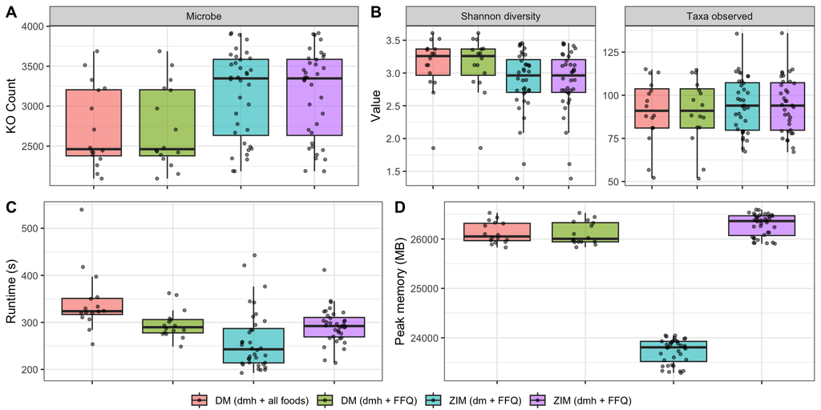

```r
plot_grid(p_size, p_diversity,
          nrow = 1, labels = c("A", "B"),
          rel_widths = c(0.8, 1)) -> top_row
plot_grid(c_runtime, c_memory,
          nrow = 1, labels = c("C", "D"),
          rel_widths = c(0.9, 1)) -> bottom_row

plot_grid(top_row, bottom_row, get_legend(legend),
          rel_heights = c(1,1,0.1),
          nrow = 3) -> f_benchmarking

f_benchmarking
```

```r
save_plot(filename = "figures/figure_b_benchmarking.png", f_benchmarking,
          base_width = 10, base_height = 7, bg= "white")
```

## Experiment differences

### Runtime and memory by experiment type

```r
# --- RUNTIME ---
df_ibd <- df %>% filter(source == "IBD (dmh + all foods)")

# Omnibus test: is there a difference across the 4 experiment types (paired by participant)?
friedman_runtime <- df_ibd %>% friedman_test(runtime_sec ~ experiment_type | participant_id)
friedman_runtime

# Effect size (Kendall's W)
df_ibd %>% friedman_effsize(runtime_sec ~ experiment_type | participant_id)

# Post-hoc pairwise paired Wilcoxon, Holm-corrected
pwc_runtime <- df_ibd %>%
  wilcox_test(runtime_sec ~ experiment_type, paired = TRUE, p.adjust.method = "holm") %>%
  add_xy_position(x = "experiment_type")

pwc_runtime

df %>%
  filter(source == "IBD (dmh + all foods)") %>%
ggplot(aes(experiment_type, runtime_sec)) +
  geom_boxplot(outlier.shape = NA, alpha = 0.6) +
  geom_line(aes(color = participant_id, group = participant_id), alpha = 0.5) +
  geom_point(aes(color = participant_id)) +
  scale_x_discrete(labels = function(x) str_wrap(experiment_labels[x], 20)) +
  labs(x = NULL, y = "Runtime (s)") +
  theme_bw() +
  theme(legend.position = "none",
        axis.text.x = element_blank()) -> p_runtime

p_runtime +
  stat_pvalue_manual(
    pwc_runtime,
    label = "p.adj",              # show adjusted p-value as a number
    hide.ns = TRUE,
    tip.length = 0.01
  ) +
  theme(plot.caption = element_text(hjust = 0.5)) +
  labs(caption = get_test_label(friedman_runtime, detailed = TRUE))-> p_runtime_stats

# --- MEMORY ---
friedman_memory <- df_ibd %>% friedman_test(peak_memory_mb ~ experiment_type | participant_id)
df_ibd %>% friedman_effsize(peak_memory_mb ~ experiment_type | participant_id)

pwc_memory <- df_ibd %>%
  wilcox_test(peak_memory_mb ~ experiment_type, paired = TRUE, p.adjust.method = "holm") %>%
  add_xy_position(x = "experiment_type")

df %>%
  filter(source == "IBD (dmh + all foods)") %>%
ggplot(aes(experiment_type, peak_memory_mb)) +
  geom_boxplot(outlier.shape = NA, alpha = 0.6) +
  geom_line(aes(color = participant_id, group = participant_id), alpha = 0.5) +
  geom_point(aes(color = participant_id)) +
  scale_x_discrete(labels = function(x) str_wrap(experiment_labels[x], 20)) +
  labs(x = NULL, y = "Peak memory (MB)") +
  theme_bw() +
  theme(legend.position = "none",
        axis.text.x = element_text(angle = 20, hjust = 1, vjust = 1)) -> p_memory

p_memory +
  stat_pvalue_manual(
    pwc_memory,
    label = "p.adj",              # show adjusted p-value as a number
    hide.ns = TRUE,
    tip.length = 0.01
  ) +
  theme(plot.caption = element_text(hjust = 0.5)) +
  labs(caption = get_test_label(friedman_memory, detailed = TRUE)) -> p_memory_stats

##### see plots rendered below in the figures section #####
```

### Network similarity: technical v biological variation

*Requires `graph_results.csv` files under the original `participants/` directory tree — not re-derived from the summary CSV used above.*

```r
# ================================================================
# read in graph_results files (aka DM[H]N output)
# GOAL: create one long format df with sample, edge, reaction, abundances
# ================================================================
participants_root <- "/Users/burkhang/Desktop/ibd_dmn/participants"

graph_files <- list.files(
  participants_root,
  pattern = "graph_results\\.csv$",
  recursive = TRUE,
  full.names = TRUE
)

# function: get one edge information - reaction, microbe read abundance and host read abundance
get_edge <- function(edge, df){
  cols <- paste0(edge, c("_reaction", "_h_abundance", "_m_abundance"))
  df %>%
    select(reaction = all_of(cols[1]),
           h        = all_of(cols[2]),
           m        = all_of(cols[3])) %>%
    filter(!is.na(reaction)) %>%
    distinct(reaction, .keep_all = TRUE) %>%   # abundance repeats across rows of same reaction
    mutate(edge = edge)
}

# function: per graph result file, get combined edge1 and edge 2 information
combine_edges <- function(file_path){
  df <- read_csv(file_path, show_col_types = F)
  bind_rows(get_edge("edge1", df), get_edge("edge2", df))
}

# combine all graph results files from all participants
suffix <- "/output_dmh/graph/graph_results\\.csv$" # this is not unique
reactions <- tibble(file_path = graph_files) %>%
  mutate(
    experiment_type = basename(str_remove(file_path, suffix)),
    participant_id  = basename(dirname(str_remove(file_path, suffix))),
    sample_id       = paste(participant_id, experiment_type, sep = "_"),
    data            = map(file_path, combine_edges)
  ) %>%
  filter(!map_lgl(data, is.null)) %>%
  select(-file_path) %>%
  unnest(data) %>%
  mutate(
    h = replace_na(h, 0),
    m = replace_na(m, 0),
    feature = paste(edge, reaction, sep = "_"),   # keeps edge position distinct
    class = case_when(
      h > 0 & m > 0 ~ "shared",
      h > 0 & m == 0 ~ "host_only",
      h == 0 & m > 0 ~ "microbe_only",
      TRUE ~ "absent"
    )
  )

### checks
# How many samples are there
n_distinct(reactions$sample_id)                                        # should be 68
# Count how many reactions are in each class
reactions %>% count(experiment_type, class)                            # class depends on method
# Does a reaction ever appear on both edges?
reactions %>% count(sample_id, reaction) %>% filter(n > 1) %>% nrow()  # most likely, yes
# Were there any reactions with no abundances?
sum(reactions$class == "absent", na.rm = T)                            # there should be none
```

```r
# ================================================================
# create sample x reaction matrices
# GOAL: create one presence/absense matrix of reactions
# ================================================================
reaction_full <- reactions %>%
  select(sample_id, feature, h, m) %>%
  complete(sample_id, feature, fill = list(h = 0, m = 0))   # adds missing combos as 0

# host matrix
mat_h <- reaction_full %>%
  select(sample_id, feature, h) %>%
  pivot_wider(names_from = feature, values_from = h) %>%
  column_to_rownames("sample_id") %>%
  as.matrix()

# microbe matrix
mat_m <- reaction_full %>%
  select(sample_id, feature, m) %>%
  pivot_wider(names_from = feature, values_from = m) %>%
  column_to_rownames("sample_id") %>%
  as.matrix()

# presence/absence: 1 if either side is above 0
mat_pa <- (mat_h > 0 | mat_m > 0) * 1

### checks
dim(mat_h); dim(mat_m); dim(mat_pa)           # should be identical: 68 x (number of reactions)
identical(dimnames(mat_h), dimnames(mat_m))   # should be TRUE

# make sure all three matrices share the same rows/cols
all_samples  <- sort(unique(reactions$sample_id))
all_features <- sort(unique(reactions$feature))

# ================================================================
# add metadata to matrix
# GOAL: create df with metadata to match matrix row names
# ================================================================
meta_rxns <- tibble(sample_id = all_samples) %>%
  left_join(distinct(reactions, sample_id, participant_id, experiment_type),
            by = "sample_id") %>%
  mutate(
    host_type    = if_else(str_starts(experiment_type, "hg_"), "genome", "transcriptome"),
    microbe_type = if_else(str_ends(experiment_type, "_mgx"), "metagenome", "metatranscriptome")
  )
stopifnot(identical(meta_rxns$sample_id, rownames(mat_pa)))
```

```r
# ================================================================
# PATTERN layer - Jaccard on reaction presence
# GOAL: Does the set of reactions detected in the patterns differ systematically
# depending on which host data type (genome vs transcriptome) and which
# microbe data type (metagenome vs metatranscriptome) was used,
# and does the effect of one depend on the other (interaction term)?
# ================================================================
set.seed(5)

d_jac <- vegdist(mat_pa, method = "jaccard", binary = TRUE)

adonis_jac <- adonis2(d_jac ~ host_type * microbe_type,
                      data = meta_rxns,
                      strata = meta_rxns$participant_id,
                      by = "terms")
print(adonis_jac)

# are group dispersions different? (PERMANOVA can't separate location from spread)
anova(betadisper(d_jac, meta_rxns$experiment_type))
```

```r
# ================================================================
# WEIGHT layer - Bray-Curtis, host and microbe sides separately
# GOAL: Among the reactions that are present,
# does the way microbial signal is distributed across them change with the data type?
# ================================================================
set.seed(5)

# divides each sample by its total so each row sums to one
rel_rows <- function(mat) {
  rs <- rowSums(mat)
  mat / ifelse(rs == 0, 1, rs)      # zero rows stay zero instead of NaN
}

# square root things so very abundance reactions don't dominate the distance
d_bc_m <- vegdist(rel_rows(sqrt(mat_m)), method = "bray")   # microbe side
d_bc_h <- vegdist(rel_rows(sqrt(mat_h)), method = "bray")   # host side

# NaN appears only if two samples are BOTH all-zero; check
sum(is.nan(d_bc_m)); sum(is.nan(d_bc_h))

adonis2(d_bc_m ~ host_type * microbe_type, data = meta_rxns,
        strata = meta_rxns$participant_id, by = "terms")

# host side: separate by host type, since genome weights are 1 and not RPKs
# (comparing hg and htx weights directly is not meaningful)
ids_htx <- meta_rxns$sample_id[meta_rxns$host_type == "transcriptome"]
d_bc_h_htx <- as.dist(as.matrix(d_bc_h)[ids_htx, ids_htx])
meta_htx   <- meta_rxns %>% filter(sample_id %in% ids_htx)
adonis2(d_bc_h_htx ~ microbe_type, data = meta_htx,
        strata = meta_htx$participant_id, permutations = 9999)
```

```r
# ================================================================
# leave-one-participant-out (checks H4039 and everyone else)
# GOAL: there is one patient that is a known outlier
# ================================================================
run_loo <- function(dist_obj) {
  dm <- as.matrix(dist_obj)
  map_dfr(unique(meta_rxns$participant_id), function(p) {
    keep <- meta_rxns$participant_id != p
    m <- meta_rxns[keep, ]
    r <- adonis2(as.dist(dm[keep, keep]) ~ host_type * microbe_type, data = m,
                 permutations = how(blocks = factor(m$participant_id), nperm = 999),
                 by = "terms")
    tibble(dropped = p, R2_host = r$R2[1], R2_microbe = r$R2[2], R2_interaction = r$R2[3])
  })
}

loo_jac <- run_loo(d_jac)
loo_bc  <- run_loo(d_bc_m)
loo_jac %>% arrange(desc(R2_microbe)) %>% head()
loo_bc %>% arrange(desc(R2_microbe)) %>% head()
summary(loo_jac$R2_microbe)
summary(loo_bc$R2_microbe)
```

```r
# ================================================================
# TURNOVER vs NESTEDNESS (microbe side)
# GOAL: when mgx and mtx differ in which reactions they detect, is it because
#   (a) turnover:    each detects reactions the other doesn't (different reactions), or
#   (b) nestedness:  one is a subset of the other (one detects fewer reactions)?
# Jaccard dissimilarity = turnover + nestedness, so this splits the Jaccard
# result you already have into two interpretable parts.
# ================================================================

# ---- 1. microbe-side presence/absence only ----
# (mat_pa used "either side" which blends host and microbe)
pa_m <- (mat_m > 0) * 1

# ---- 2. handle empty samples ----
# An empty row (no microbe signal at all, e.g. H4039 hg_mtx) makes turnover 0/0 = NaN,
# and nestedness is trivially 1 (empty set is a subset of anything).
# So that sample can't be used in the decomposition. Drop it and report it.
empty <- rownames(pa_m)[rowSums(pa_m) == 0]
empty

keep  <- !(rownames(pa_m) %in% empty)
pa_m2 <- pa_m[keep, ]
meta2 <- meta_rxns[keep, ]
stopifnot(identical(meta2$sample_id, rownames(pa_m2)))

# ---- 3. decompose Jaccard ----
bp <- beta.pair(pa_m2, index.family = "jaccard")
# bp$beta.jtu = turnover   (replacement of reactions)
# bp$beta.jne = nestedness (difference in richness, one set contained in the other)
# bp$beta.jac = total Jaccard dissimilarity

# sanity checks: parts should add up to the total, and match vegan's Jaccard
all.equal(as.numeric(bp$beta.jac), as.numeric(bp$beta.jtu + bp$beta.jne))
all.equal(as.numeric(bp$beta.jac),
          as.numeric(vegdist(pa_m2, "jaccard", binary = TRUE)))
sum(is.nan(bp$beta.jtu)); sum(is.nan(bp$beta.jne))   # should be 0

# ================================================================
# 4. PERMANOVA on each component
# Does host_type / microbe_type shift turnover? nestedness?
# Permutations are blocked by participant, as before.
# Note: these are not Euclidean distances, so a negative SumOfSqs can
# appear (treat as ~0), as with your Jaccard interaction.
# ================================================================
set.seed(5)
perm_design <- how(blocks = factor(meta2$participant_id), nperm = 9999) # this equals strata

test_component <- function(d, label) {
  res <- adonis2(d ~ host_type * microbe_type, data = meta2,
                 permutations = perm_design, by = "terms")
  tibble(component = label,
         term = rownames(res)[1:3],
         R2   = res$R2[1:3],
         p    = res$`Pr(>F)`[1:3])
}

component_tests <- bind_rows(
  test_component(bp$beta.jac, "total Jaccard"),
  test_component(bp$beta.jtu, "turnover"),
  test_component(bp$beta.jne, "nestedness")
)
print(component_tests)

# ================================================================
# 5. PAIRED, WITHIN-PARTICIPANT VIEW
# The PERMANOVA says whether the components shift with method.
# This says how much of each mgx-vs-mtx difference is turnover vs nestedness,
# and which direction the subset goes.
# ================================================================
jtu_m <- as.matrix(bp$beta.jtu)
jne_m <- as.matrix(bp$beta.jne)
jac_m <- as.matrix(bp$beta.jac)

# one row per participant x host_type, with the mgx and mtx sample IDs side by side
paired <- meta2 %>%
  select(participant_id, host_type, microbe_type, sample_id) %>%
  pivot_wider(names_from = microbe_type, values_from = sample_id) %>%
  drop_na()    # participants missing one of the two samples (e.g. the dropped one)

paired <- paired %>%
  mutate(
    jac = map2_dbl(metagenome, metatranscriptome, ~ jac_m[.x, .y]),
    jtu = map2_dbl(metagenome, metatranscriptome, ~ jtu_m[.x, .y]),
    jne = map2_dbl(metagenome, metatranscriptome, ~ jne_m[.x, .y]),

    n_mg = map_dbl(metagenome,        ~ sum(pa_m2[.x, ])),
    n_mt = map_dbl(metatranscriptome, ~ sum(pa_m2[.x, ])),

    # direction: of the reactions seen in mtx, what fraction are also seen in mgx?
    frac_mt_in_mg = map2_dbl(metagenome, metatranscriptome,
                             ~ sum(pa_m2[.x, ] & pa_m2[.y, ]) / sum(pa_m2[.y, ])),
    # and the reverse
    frac_mg_in_mt = map2_dbl(metagenome, metatranscriptome,
                             ~ sum(pa_m2[.x, ] & pa_m2[.y, ]) / sum(pa_m2[.x, ])),

    nest_share = jne / jac     # fraction of the difference that is nestedness
  )

paired_summary <- paired %>%
  group_by(host_type) %>%
  summarise(
    n_pairs             = n(),
    median_richness_mg  = median(n_mg),
    median_richness_mt  = median(n_mt),
    median_jtu          = median(jtu),
    median_jne          = median(jne),
    median_nest_share   = median(nest_share, na.rm = TRUE),
    median_mt_in_mg     = median(frac_mt_in_mg),
    median_mg_in_mt     = median(frac_mg_in_mt),
    # paired test: is nestedness larger than turnover within a participant?
    p_jne_vs_jtu        = wilcox.test(jne, jtu, paired = TRUE, exact = FALSE)$p.value,
    # paired test: does mtx detect fewer reactions than mgx?
    p_richness          = wilcox.test(n_mt, n_mg, paired = TRUE, exact = FALSE)$p.value
  )
print(paired_summary)
```

```r
# ================================================================
# Lost v kept
# GOAL: identifying lost and kept reactinos accross methods
# ================================================================

lost_vs_kept <- paired %>%
  mutate(
    lost_ab = map2(metagenome, metatranscriptome, function(mg, mt) {
      lost <- pa_m2[mg, ] == 1 & pa_m2[mt, ] == 0
      mat_m[mg, lost]
    }),
    kept_ab = map2(metagenome, metatranscriptome, function(mg, mt) {
      kept <- pa_m2[mg, ] == 1 & pa_m2[mt, ] == 1
      mat_m[mg, kept]
    }),
    median_lost = map_dbl(lost_ab, median),
    median_kept = map_dbl(kept_ab, median),
    # share of lost reactions that sit above the median mgx abundance for that sample
    frac_lost_above_median = map2_dbl(lost_ab, metagenome, function(l, mg) {
      ab <- mat_m[mg, pa_m2[mg, ] == 1]
      mean(l > median(ab))
    })
  )

lost_vs_kept %>%
  group_by(host_type) %>%
  summarise(
    n                  = n(),
    med_of_median_lost = median(median_lost),
    med_of_median_kept = median(median_kept),
    med_frac_above     = median(frac_lost_above_median),
    p_lost_vs_kept     = wilcox.test(median_lost, median_kept, paired = TRUE, exact = FALSE)$p.value,
    p_frac_vs_half     = wilcox.test(frac_lost_above_median, mu = 0.5, exact = FALSE)$p.value
  )
```

```r
# ---------- helpers ----------
perm_for <- function(m, nperm = 9999) how(blocks = factor(m$participant_id), nperm = nperm)
sub_dist <- function(d, ids) as.dist(as.matrix(d)[ids, ids])
fmt_p    <- function(p) if_else(p <= 1e-4, "p \u2264 0.0001", paste0("p = ", sprintf("%.4f", p)))

run_adonis <- function(d, m, analysis, rhs = "host_type * microbe_type") {
  set.seed(5)
  res <- adonis2(as.formula(paste("d ~", rhs)), data = m,
                 permutations = perm_for(m), by = "terms")
  tibble(analysis = analysis,
         term = rownames(res), df = res$Df,
         R2 = res$R2, F = res$F, p = res$`Pr(>F)`) %>%
    filter(!term %in% c("Residual", "Total"))
}

# ---------- distances ----------
# (d_jac, d_bc_m, meta_rxns, pa_m2, meta2 already exist)
d_jac_m  <- vegdist(pa_m2, method = "jaccard", binary = TRUE)   # microbe-side presence
ids_keep <- meta2$sample_id                                     # drops H4039 hg_mtx (no microbe signal)
d_bc_m2  <- sub_dist(d_bc_m, ids_keep)

ids_htx  <- meta_rxns$sample_id[meta_rxns$host_type == "transcriptome"]
meta_htx <- meta_rxns %>% filter(sample_id %in% ids_htx)
d_bc_h_htx <- sub_dist(d_bc_h, ids_htx)

# ================================================================
# Testing the effect of disease status (only host = transcriptome)
# ================================================================
clin_p <- meta %>%
  select(`Participant ID`, week_num, diagnosis) %>%
  mutate(participant_id = paste0(`Participant ID`, "_week", week_num)) %>%
  select(-c(`Participant ID`, week_num)) %>%
  distinct()

one_per <- meta2 %>%
  distinct(participant_id) %>%
  left_join(clin_p, by = "participant_id")

one_per %>% count(diagnosis)       # cell sizes

# paired data has two rows per participant, one for each host type, but microbe-abundance stays the same
loss <- paired %>%
  filter(host_type == "transcriptome") %>%
  mutate(frac_lost = 1 - n_mt / n_mg) %>%
  left_join(clin_p, by = "participant_id")

# table
loss %>% group_by(diagnosis) %>%
  summarise(n = n(), median = median(frac_lost),
            min = min(frac_lost), max = max(frac_lost), .groups = "drop")

# plot 1: paired shift
loss %>%
  pivot_longer(c(n_mg, n_mt), names_to = "microbe", values_to = "n_reactions") %>%
  mutate(microbe = case_when(microbe == "n_mg" ~ "mgx", microbe == "n_mt" ~ "mtx")) %>%
  ggplot(aes(microbe, n_reactions, group = participant_id, color = diagnosis)) +
  geom_line() + geom_point(size = 2.5) + theme_bw(base_size = 13)

# plot 2: depth
depth <- tibble(sample_id = rownames(mat_m), total_m = rowSums(mat_m))
loss2 <- loss %>%
  left_join(depth, by = c("metatranscriptome" = "sample_id")) %>%
  left_join(depth, by = c("metagenome" = "sample_id"), suffix = c("_mt", "_mg"))
loss2 %>%
  pivot_longer(c(total_m_mg, total_m_mt), names_to = "method", values_to = "total_m") %>%
  mutate(method = if_else(method == "total_m_mg", "Metagenome", "Metatranscriptome")) %>%
  ggplot(aes(total_m, frac_lost, color = diagnosis)) +
  geom_point(size = 3) +
  scale_x_log10() +
  facet_wrap(~ method, scales = "free_x") +
  labs(x = "Total microbial abundance (RPK, log scale)",
       y = "Net reduction in reactions\ndetected (1 - mtx/mgx)") +
  theme_bw(base_size = 13)

# one exploratory test: interaction only
# (blocked permutations are valid for this term, not for the main effect)
ids <- meta2 %>% filter(host_type == "transcriptome") %>% left_join(clin_p, by = "participant_id")
dd  <- sub_dist(d_bc_m2, ids$sample_id)
adonis2(dd ~ microbe_type * diagnosis, data = ids,
        permutations = how(blocks = factor(ids$participant_id), nperm = 9999),
        by = "terms")

# for robustness check replicate this in human reference genome
loss_hg <- paired %>%
  filter(host_type == "genome") %>%              # 16 pairs; H4039 excluded (no hg_mtx signal)
  mutate(frac_lost = 1 - n_mt / n_mg) %>%
  left_join(depth, by = c("metatranscriptome" = "sample_id")) %>%
  left_join(depth, by = c("metagenome" = "sample_id"), suffix = c("_mt", "_mg"))

cor.test(loss_hg$frac_lost, loss_hg$total_m_mt, method = "spearman", exact = FALSE)
cor.test(loss_hg$frac_lost, loss_hg$total_m_mg, method = "spearman", exact = FALSE)
```

### Tables

```r
# ================================================================
# Table 1: PERMANOVA
# Use the numeric version of the table, not the formatted strings,
# so gt can format p-values itself
# ================================================================
permanova_gt_data <- bind_rows(
  run_adonis(d_jac,      meta_rxns, "Pattern: presence, host + microbe side"),
  run_adonis(d_jac_m,    meta2,     "Pattern: presence, microbe side"),
  run_adonis(d_bc_m2,    meta2,     "Weight: Bray-Curtis, microbe side"),
  run_adonis(d_bc_h_htx, meta_htx,  "Weight: Bray-Curtis, host side (transcriptome only)",
             rhs = "microbe_type")
) %>%
  group_by(analysis) %>%
  mutate(p_adj = p.adjust(p, method = "BH")) %>%
  ungroup() %>%
  mutate(term = str_replace_all(term, c("host_type" = "Host data",
                                        "microbe_type" = "Microbe data")))

tbl_permanova <- permanova_gt_data %>%
  gt(groupname_col = "analysis", rowname_col = "term") %>%
  tab_header(
    title = "PERMANOVA by data type",
    subtitle = "9,999 permutations, restricted within participant"
  ) %>%
  cols_label(df = "Df", R2 = md("R<sup>2</sup>"), F = "F",
             p = "p", p_adj = "BH-adj. p") %>%
  fmt_number(columns = c(R2, F), decimals = 3) %>%
  fmt_number(columns = c(p, p_adj), decimals = 4) %>%
  sub_small_vals(columns = c(p, p_adj), threshold = 0.0001) %>%   # shows "<0.0001"
  tab_style(style = cell_text(weight = "bold"),
            locations = cells_body(columns = c(p, p_adj), rows = p_adj < 0.05)) %>%
  tab_footnote("Negative R\u00B2 values arise from non-Euclidean distances and are treated as approximately 0.") %>%
  tab_footnote("Host-side weights are compared within transcriptome samples only (genome weights are KO counts, not RPKs).") %>%
  opt_table_font(font = "Arial")

gtsave(tbl_permanova, "tables/table1_permanova.png", vwidth = 1100, zoom = 2)

# ================================================================
# Table 2: mtx vs mgx detection and nestedness
# ================================================================
lost_summary <- lost_vs_kept %>%
  group_by(host_type) %>%
  summarise(median_abund_lost = median(median_lost),
            median_abund_kept = median(median_kept),
            pct_lost_above_median = 100 * median(frac_lost_above_median),
            .groups = "drop")

detection_table <- paired_summary %>%
  select(host_type, n_pairs, median_richness_mg, median_richness_mt,
         median_jtu, median_jne, median_nest_share, median_mt_in_mg, median_mg_in_mt) %>%
  left_join(lost_summary, by = "host_type") %>%
  mutate(across(where(is.numeric), ~ round(.x, 3)))

tbl_detection <- detection_table %>%
  mutate(host_type = dplyr::recode(host_type, genome = "Host genome",
                            transcriptome = "Host transcriptome")) %>%
  gt(rowname_col = "host_type") %>%
  tab_header(title = "Metatranscriptome vs metagenome reaction detection",
             subtitle = "Within-participant medians") %>%
  tab_spanner(label = "Reactions detected",
              columns = c(median_richness_mg, median_richness_mt)) %>%
  tab_spanner(label = "Dissimilarity components",
              columns = c(median_jtu, median_jne, median_nest_share)) %>%
  tab_spanner(label = "Overlap",
              columns = c(median_mt_in_mg, median_mg_in_mt)) %>%
  tab_spanner(label = "Median mgx abundance",
              columns = c(median_abund_lost, median_abund_kept)) %>%
  cols_label(
    n_pairs = "Pairs",
    median_richness_mg = "mgx", median_richness_mt = "mtx",
    median_jtu = "Turnover", median_jne = "Nestedness",
    median_nest_share = "Nestedness share",
    median_mt_in_mg = "mtx in mgx", median_mg_in_mt = "mgx in mtx",
    median_abund_lost = "Lost in mtx", median_abund_kept = "Kept in mtx",
    pct_lost_above_median = "% lost above sample median"
  ) %>%
  fmt_number(columns = c(median_richness_mg, median_richness_mt,
                         median_abund_lost, median_abund_kept), decimals = 0) %>%
  fmt_number(columns = c(median_jtu, median_jne, median_nest_share,
                         median_mt_in_mg, median_mg_in_mt), decimals = 2) %>%
  fmt_number(columns = pct_lost_above_median, decimals = 1) %>%
  tab_footnote("H4039 hg_mtx excluded (no microbe signal), so the genome row has 16 pairs.") %>%
  opt_table_font(font = "Arial")

gtsave(tbl_detection, "tables/table2_detection.png", vwidth = 1400, zoom = 2)
```

### Figures

```r
pcoa_panel <- function(d, m, title) {
  pc <- cmdscale(d, k = 2, eig = TRUE)
  ve <- round(100 * pc$eig / sum(pc$eig[pc$eig > 0]), 1)   # approximate for Jaccard (negative eigenvalues)

  df <- as.data.frame(pc$points) %>%
    setNames(c("PCoA1", "PCoA2")) %>%
    mutate(sample_id = rownames(pc$points)) %>%
    left_join(m, by = "sample_id")

  # per-panel PERMANOVA: microbe effect within each host type, blocked by participant
  ann <- map_dfr(c("genome", "transcriptome"), function(h) {
    ids <- m$sample_id[m$host_type == h]
    mm  <- m %>% filter(sample_id %in% ids)
    dd  <- sub_dist(d, ids)
    set.seed(5)
    r <- adonis2(dd ~ microbe_type, data = mm, permutations = perm_for(mm))
    tibble(host_type = h, label = paste0("R\u00B2 = ", round(r$R2[1], 3), ", ", fmt_p(r$`Pr(>F)`[1])))
  })

  ggplot(df, aes(PCoA1, PCoA2)) +
    geom_line(aes(group = participant_id), color = "grey75", alpha = 0.5, linewidth = 0.4) +
    geom_point(aes(color = microbe_type), size = 3, alpha = 0.9) +
    stat_ellipse(aes(color = microbe_type), linetype = "dashed", linewidth = 0.5) +
    geom_hline(yintercept = 0, color = "black", linetype = "dashed") +
    geom_vline(xintercept = 0, color = "black", linetype = "dashed") +
    geom_text(data = filter(df, str_starts(participant_id, "H4039")),
              aes(label = "H4039"), vjust = -1, size = 3) +
    geom_text(data = ann, aes(x = Inf, y = Inf, label = label),
              hjust = 1.05, vjust = 1.5, size = 3.3, inherit.aes = FALSE) +
    facet_wrap(~ host_type, ncol = 1,
               labeller = labeller(host_type = c(genome = "Host genome",
                                                 transcriptome = "Host transcriptome"))) +
    scale_color_manual(values = c(metagenome = "#009E73", metatranscriptome = "#CC79A7"),
                       name = "Microbial method") +
    labs(title = title,
         x = paste0("PCoA1 (", ve[1], "%)"), y = paste0("PCoA2 (", ve[2], "%)")) +
    theme_bw(base_size = 13) +
    theme(strip.text = element_text(face = "bold"),
          plot.title = element_text(hjust = 0.5))
}

p_pattern <- pcoa_panel(d_jac_m, meta2, "Reaction presence (Jaccard)")
p_weight  <- pcoa_panel(d_bc_m2,  meta2, "Reaction abundance (Bray-Curtis)")

fig_pcoa <- (p_pattern | p_weight) +
  plot_layout(guides = "collect") &
  theme(legend.position = "bottom")

fig_pcoa

fig_richness <- paired %>%
  select(participant_id, host_type, n_mg, n_mt) %>%
  pivot_longer(c(n_mg, n_mt), names_to = "microbe", values_to = "n_reactions") %>%
  mutate(microbe = dplyr::recode(microbe, n_mg = "Metagenome", n_mt = "Metatranscriptome"),
         host_type = dplyr::recode(host_type, genome = "Host genome", transcriptome = "Host transcriptome")) %>%
  ggplot(aes(microbe, n_reactions, group = participant_id)) +
  geom_line(color = "grey70") +
  geom_point(aes(color = microbe), size = 2.5) +
  facet_wrap(~ host_type) +
  scale_color_manual(values = c(Metagenome = "#009E73", Metatranscriptome = "#CC79A7"), guide = "none") +
  labs(x = NULL, y = "Reactions detected") +
  theme_bw(base_size = 13)

fig_richness
```

```r
plot_grid(p_runtime_stats, p_memory_stats,
          nrow = 2, ncol = 1, labels = c("A", "B"),
          rel_heights = c(0.9, 1)) -> left_column

plot_grid(left_column, pcoa_plot_faceted,
          nrow = 1, ncol = 2, labels = c("", "C")) -> experiment_type_benchmarking

experiment_type_benchmarking
save_plot(filename = "figures/figure_b_experiment_type_benchmarking.png", experiment_type_benchmarking,
          base_height = 9, base_width = 11)
```

[output not shown]

### Summary of Findings

#### Data setup

- **Input:** one long table (`reactions`) with `sample_id`, `participant_id`, `experiment_type`, `edge`, `reaction`, `h`, `m`.
  - 68 samples (17 participants $\times$ 4 methods).
  - 0 reactions with no signal on either side.
- **Deduplication:** abundance repeats across rows of the same reaction, so keep one row per reaction per edge.
- **Features:** `edge_reaction`, which keeps edge position distinct.
  - About 185 reactions per sample appear on both edges and are counted twice (see sensitivity checks).
- **Matrices:** sample $\times$ reaction matrices, all 68 $\times$ 1083.
  - `mat_h`: host abundance.
  - `mat_m`: microbe abundance.
  - `mat_pa`: presence/absence (signal on either side).
- **Class counts:** host-only, microbe-only and shared reactions per method.
  - Host type barely changes the class counts.
  - Metatranscriptome (mtx) has about half as many microbe-only reactions as metagenome (mgx): about 2,300-2,400 vs 4,500.

#### Why this replaces the earlier code

- **Edge sums were too coarse.** Per-edge sums cannot show which reactions differ, and the motif-level Bray-Curtis compared only two independent numbers.
- **`host_dominance` and `handoff_shift` were scale artifacts.**
  - Genome weights are about 280 (KO counts), versus about $10^6$ for the transcriptome and about $10^5$ for the microbe.
  - Do not compare them across host types.
- **`edge2_*_rel` was redundant** ($\text{edge2} = 1 - \text{edge1}$).

#### Analysis 1: pattern (Jaccard on presence)

- **Question:** does the set of detected reactions depend on host type, microbe type, or both?
- **Method:** `adonis2(d_jac ~ host_type * microbe_type)`, permutations blocked by participant, plus `betadisper`.
- **Results (presence on either side):**
  - Microbe type: $R^2 = 0.137$, $p = 0.001$.
  - Host type: $R^2 = 0.027$, $p = 0.032$.
  - Interaction: about 0 (the small negative value is a non-Euclidean artifact).
  - `betadisper`: $p = 0.24$, so these are location effects, not dispersion.
- **Results (microbe side only, H4039 `hg_mtx` excluded):**
  - Microbe type: $R^2 = 0.181$, $p < 0.001$.
  - Host type: $R^2 = 0.014$, $p = 0.20$.
  - Interaction: about 0.
  - The earlier host effect therefore came from the host side of the reaction set.

#### Analysis 2: weight (Bray-Curtis on abundance)

- **Question:** among present reactions, is the signal distributed differently across them by data type?
- **Method:** square root (to reduce dominance of abundant reactions), row-normalize, then Bray-Curtis. Host and microbe sides are kept separate.
- **Microbe side:**
  - Microbe type: $R^2 = 0.166$, $p = 0.001$.
  - Host type: $R^2 = 0.009$, $p = 0.46$.
  - Interaction: about 0.
  - The non-significant host effect on the microbe side serves as a negative control (microbial input is identical across host pairings), and behaves as expected.
- **Host side:** within transcriptome (`htx`) samples only, since genome weights are not RPKs.
  - Microbe type: $R^2 = 0.062$, $p = 0.024$.
  - This probably reflects which reactions are in the graph, not changed host expression.
- **Empty rows:** H4039 `hg_mtx` has no microbe signal.
  - After row-normalization its distance to other samples is 1.
  - The `vegdist` warning is expected.

#### Analysis 3: influence of H4039

- **Method:** leave-one-participant-out PERMANOVA for Jaccard and Bray-Curtis.
- **Result:** dropping H4039 raises the microbe $R^2$.
  - Jaccard: 0.137 to 0.263.
  - Bray-Curtis: 0.166 to 0.259.
  - The next most influential participants sit at about 0.14-0.19.
  - H4039 weakens the effect, so the conclusions do not depend on it.
- **Handling:**
  - H4039 `hg_mtx` is excluded from decomposition steps because an empty set makes turnover undefined.
  - Report it as a separate case, not as noise.

#### Analysis 4: turnover vs nestedness (microbe side)

- **Question:** when mgx and mtx differ, do they detect different reactions (turnover) or is one a subset of the other (nestedness)?
- **Method:** `betapart::beta.pair`, which splits Jaccard into turnover (`jtu`) and nestedness (`jne`).
  - Sanity checks pass: the parts sum to the total and match `vegdist`.
- **Paired results (within participant, mgx vs mtx):**
  - Median richness falls from about 654 to about 450 reactions ($p < 0.001$).
  - Nestedness is about 0.35 and turnover about 0.025, so nestedness is about 93% of the dissimilarity.
  - About 99% of mtx reactions are also in mgx, but only about 64% of mgx reactions are in mtx.
- **Interpretation:** mtx is a thinned subset of mgx, not a different set of reactions.
- **Reporting notes:**
  - Do not report the negative $R^2$ for the turnover PERMANOVA.
  - $R^2$ is not additive across components, so compare the paired medians instead.

#### Analysis 5: what is lost in mtx

- **Question:** are the reactions missing from mtx the low-abundance ones?
- **Results:**
  - Lost reactions have a median mgx abundance of about 7. Kept reactions have about 155.
  - Only 14-15% of lost reactions are above that sample’s median abundance (50% expected if unrelated).
  - The direction is the same in all participants (16/16 genome, 17/17 transcriptome), so p-values sit at their floor.
- **Interpretation:**
  - Consistent with a detection threshold: what is lost is predicted by DNA abundance.
  - This does not prove sensitivity is the only cause, since low abundance could also reflect low expression.

## Overall conclusions

- **Microbe data type** is the main driver of which reactions are detected and how their abundance is distributed.
  - mtx reaction sets were almost entirely nested within mgx sets (about 99% of mtx reactions were also in mgx).
  - Differences were mostly missing reactions in mtx, not different reactions.
- **Host data type** had no meaningful effect on microbial results, and there was no interaction with microbe data type.
  - The host genome supplies presence only (each KO weighted 1), so host abundance can only be compared in graphs built with the host transcriptome.
- **Reactions missing from mtx were mostly low-abundance in mgx** (median about 7 vs about 155 for retained reactions).
- **Loss tracked mtx total microbial signal and not mgx signal** (Spearman $\rho = -0.76$ and $-0.72$ in the two host pairings; $\rho \approx 0.1$-$0.2$ for mgx).
  - The two lowest-signal samples (H4039 mtx, M2026 mgx) had the fewest detected reactions in that method.
  - This is consistent with a detection limit in low-signal metatranscriptomes, though it does not exclude true differences in expression.
- **Diagnosis and antibiotic exposure** could not be evaluated at this sample size ($n = 17$; UC 3, non-IBD 4, CD 10).
  - Apparent group differences in loss were confounded with total microbial signal.